# Lab 4: Childcare Costs in California

Author

Ryan Chan

## The Data

In this lab we’re going look at the median weekly cost of childcare in California. A detailed description of the data can be found [here](https://github.com/rfordatascience/tidytuesday/blob/master/data/2023/2023-05-09/readme.md).

The data come to us from [TidyTuesday](https://github.com/rfordatascience/tidytuesday).

**0. Load the appropriate libraries and the data.**

```r
# code chunk for loading packages
library(tidyverse)
library(scales)
```

```r
childcare_costs <- read_csv('https://raw.githubusercontent.com/rfordatascience/tidytuesday/master/data/2023/2023-05-09/childcare_costs.csv',
                            show_col_types = FALSE)

counties <- read_csv('https://raw.githubusercontent.com/rfordatascience/tidytuesday/master/data/2023/2023-05-09/counties.csv',
                     show_col_types = FALSE)
```

**1. Briefly describe the dataset (~ 4 sentences). What information does it contain?**

```r
summary(childcare_costs, class)
```

```
 county_fips_code   study_year       unr_16          funr_16
 Min.   : 1001    Min.   :2008   Min.   : 0.000   Min.   : 0.000
 1st Qu.:18177    1st Qu.:2010   1st Qu.: 5.100   1st Qu.: 4.640
 Median :29177    Median :2013   Median : 7.050   Median : 6.590
 Mean   :30388    Mean   :2013   Mean   : 7.466   Mean   : 7.029
 3rd Qu.:45081    3rd Qu.:2016   3rd Qu.: 9.350   3rd Qu.: 8.880
 Max.   :56045    Max.   :2018   Max.   :36.110   Max.   :38.240

    munr_16        unr_20to64    funr_20to64      munr_20to64
 Min.   : 0.00   Min.   : 0.0   Min.   : 0.000   Min.   : 0.000
 1st Qu.: 5.20   1st Qu.: 4.6   1st Qu.: 4.200   1st Qu.: 4.700
 Median : 7.39   Median : 6.5   Median : 6.000   Median : 6.800
 Mean   : 7.86   Mean   : 6.9   Mean   : 6.482   Mean   : 7.275
 3rd Qu.: 9.92   3rd Qu.: 8.7   3rd Qu.: 8.250   3rd Qu.: 9.200
 Max.   :39.74   Max.   :33.9   Max.   :44.500   Max.   :45.500

  flfpr_20to64    flfpr_20to64_under6 flfpr_20to64_6to17
 Min.   : 33.60   Min.   :  0.00      Min.   :  0.00
 1st Qu.: 65.10   1st Qu.: 62.60      1st Qu.: 74.40
 Median : 70.60   Median : 69.60      Median : 79.45
 Mean   : 70.09   Mean   : 68.82      Mean   : 78.82
 3rd Qu.: 75.50   3rd Qu.: 76.10      3rd Qu.: 84.22
 Max.   :100.00   Max.   :100.00      Max.   :100.00

 flfpr_20to64_under6_6to17  mlfpr_20to64         pr_f            pr_p
 Min.   :  0.00            Min.   :  8.20   Min.   : 0.00   Min.   : 0.00
 1st Qu.: 59.80            1st Qu.: 74.20   1st Qu.: 7.70   1st Qu.:11.40
 Median : 67.66            Median : 81.00   Median :10.90   Median :15.20
 Mean   : 66.94            Mean   : 78.64   Mean   :11.74   Mean   :16.04
 3rd Qu.: 75.20            3rd Qu.: 85.90   3rd Qu.:14.60   3rd Qu.:19.50
 Max.   :100.00            Max.   :100.00   Max.   :52.10   Max.   :55.10

    mhi_2018         me_2018         fme_2018        mme_2018
 Min.   : 19842   Min.   : 4947   Min.   : 5019   Min.   : 4238
 1st Qu.: 41839   1st Qu.:25955   1st Qu.:20613   1st Qu.:31448
 Median : 48506   Median :28654   Median :22855   Median :35103
 Mean   : 50447   Mean   :29404   Mean   :23475   Mean   :35997
 3rd Qu.: 56201   3rd Qu.:32006   3rd Qu.:25635   3rd Qu.:39503
 Max.   :136268   Max.   :70565   Max.   :68600   Max.   :98580

```

[output cut: 73 more lines]

```
 Min.   : 27.73   Min.   : 21.54   Min.   : 21.54   Min.   : 43.08
 1st Qu.:108.75   1st Qu.:100.00   1st Qu.: 95.88   1st Qu.: 90.00
 Median :134.50   Median :120.99   Median :113.99   Median :106.00
 Mean   :146.05   Mean   :130.48   Mean   :122.23   Mean   :113.42
 3rd Qu.:166.33   3rd Qu.:148.71   3rd Qu.:139.30   3rd Qu.:129.31
 Max.   :470.00   Max.   :419.00   Max.   :385.00   Max.   :430.94
 NA's   :10974    NA's   :10974    NA's   :10974    NA's   :11184
  mfcc_toddler    mfcc_preschool
 Min.   : 43.08   Min.   : 40.03
 1st Qu.: 85.08   1st Qu.: 84.25
 Median :100.25   Median : 99.65
 Mean   :106.76   Mean   :104.19
 3rd Qu.:124.95   3rd Qu.:120.20
 Max.   :376.32   Max.   :331.34
 NA's   :11184    NA's   :11184
```

```r
summary(counties, class)
```

```
 county_fips_code county_name         state_name        state_abbreviation
 Min.   : 1001    Length:3144        Length:3144        Length:3144
 1st Qu.:18176    Class :character   Class :character   Class :character
 Median :29176    Mode  :character   Mode  :character   Mode  :character
 Mean   :30381
 3rd Qu.:45082
 Max.   :56045
```

The dataset, comprising the `childcare_costs` and `counties` dataframes, contains information on childcare costs with respect to many different counties across counties in the United States. The `childcare_costs` table includes various demographic and economic indicators related to childcare in different counties. This includes columns such as unemployment rates, labor force participation rates, and median household income. The `counties` table provides county information, mapping county identifiers to the county name and state.

## California Childcare Costs

Let’s start by focusing only on California.

```r
ca_childcare <- counties |>
  inner_join(childcare_costs,
             by = join_by(county_fips_code)) |>
  filter(state_name == "California")
```

**3. Using a function from the `forcats` package, complete the code below to create a new variable where each county is categorized into one of the [10 Census regions](https://census.ca.gov/regions/) in California. Use the Region description (from the plot), not the Region number.**  
*Hint: This is probably a good place to use ChatGPT to reduce on tedious work. But you do need to know how to prompt ChatGPT to make it useful!*

```r
# Source: class-provided ChatGPT conversation: https://chatgpt.com/share/6711724e-55d0-8012-bfd7-d5831106c443
# Note: the regions categorized by ChatGPT were incorrect, so manually fixed the region to county mappings

ca_childcare <- ca_childcare |>
  mutate(county_name = str_remove(county_name, " County"),
         region = fct_collapse(county_name,
                               "Superior California" = c("Butte", "Colusa", "El Dorado", "Glenn", "Lassen", "Modoc", "Nevada", "Placer", "Plumas", "Sacramento", "Shasta", "Sierra", "Siskiyou", "Sutter", "Tehama", "Yolo", "Yuba"),
                               "North Coast" = c("Del Norte", "Humboldt", "Lake", "Mendocino", "Napa", "Sonoma", "Trinity"),
                               "San Francisco Bay Area" = c("Alameda", "Contra Costa", "Marin", "San Francisco", "San Mateo", "Santa Clara", "Solano"),
                               "Northern San Joaquin Valley" = c("Alpine", "Amador", "Calaveras", "Madera", "Mariposa", "Merced", "Mono", "San Joaquin", "Stanislaus", "Tuolumne"),
                               "Central Coast" = c("Monterey", "San Benito", "San Luis Obispo", "Santa Barbara", "Santa Cruz", "Ventura"),
                               "Southern San Joaquin Valley" = c("Fresno", "Inyo", "Kern", "Kings", "Tulare"),
                               "Inland Empire" = c("Riverside", "San Bernardino"),
                               "Los Angeles County" = c("Los Angeles"),
                               "Orange County" = c("Orange"),
                               "San Diego-Imperial" = c("San Diego", "Imperial")))
```

**4. Let’s consider the median household income of each region, and how that income has changed over time. Create a table with ten rows, one for each region, and two columns, one for 2008 and one for 2018. The cells should contain the `median` of the median household income (expressed in 2018 dollars) of the `region` and the `study_year`. Arrange the rows by 2018 values.**

```r
# pivot the table to wider for 2008 and 2018 values
ca_childcare |>
  group_by(region, study_year) |>
  filter(study_year %in% c(2008, 2018)) |>
  summarize(median_mhi = median(mhi_2018,
                                na.rm = TRUE)) |>
  pivot_wider(names_from = study_year,
              values_from = median_mhi) |>
  arrange(desc(`2018`))
```

```
# A tibble: 10 × 3
# Groups:   region [10]
   region                      `2008`  `2018`
   <fct>                        <dbl>   <dbl>
 1 San Francisco Bay Area      90412. 104552
 2 Orange County               86452.  85398
 3 Central Coast               72979   74849
 4 Los Angeles County          63471.  64251
 5 Inland Empire               65977.  62056
 6 San Diego-Imperial          58201.  60344.
 7 Northern San Joaquin Valley 59108.  57769
 8 Superior California         57831.  53270
 9 Southern San Joaquin Valley 52676.  52479
10 North Coast                 47862.  45528
```

**5. Which California `region` had the lowest `median` full-time median weekly price for center-based childcare for infants in 2018? Does this `region` correspond to the `region` with the lowest `median` income in 2018 that you found in Q4?**  
*Hint: The code should give me the EXACT answer. This means having the code output the exact row(s) and variable(s) necessary for providing the solution.*

```r
ca_childcare |>
  group_by(region) |>
  filter(study_year == 2018) |>
  summarize(median_mc = median(mc_infant,
                               na.rm = TRUE)) |>
  slice_min(median_mc)
```

```
# A tibble: 1 × 2
  region              median_mc
  <fct>                   <dbl>
1 Superior California      215.
```

The Superior California region accounted for the lowest `median` full-time median weekly price for center-base childcare for infants in 2018. This does not correspond to the region with the lowest median household income in 2018, which was the North Coast region based on the table in the previous question.

**6. The following plot shows, for all ten regions, the change over time of the full-time median price for center-based childcare for infants, toddlers, and preschoolers. Recreate the plot. You do not have to replicate the exact colors or theme, but your plot should have the same content, including the order of the facets and legend, reader-friendly labels, axes breaks, and a loess smoother.**

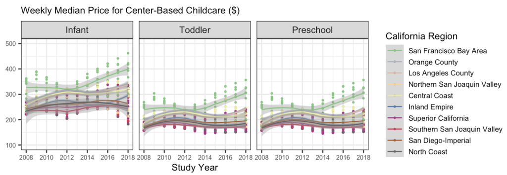

Plot to recreate

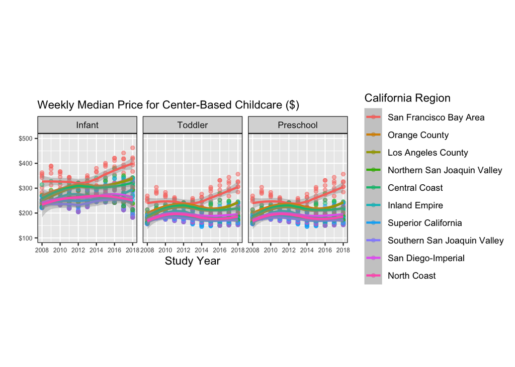

```r
# Source: https://scales.r-lib.org/reference/label_currency.html
# Improving the plot by adding $ to y-axis labels

# specify exact region order in legend
region_order <- c("San Francisco Bay Area",
                  "Orange County",
                  "Los Angeles County",
                  "Northern San Joaquin Valley",
                  "Central Coast",
                  "Inland Empire",
                  "Superior California",
                  "Southern San Joaquin Valley",
                  "San Diego-Imperial",
                  "North Coast")

# data cleaning before piping into the plot
ca_childcare |>
  filter(!is.na(mc_infant),
         !is.na(mc_toddler),
         !is.na(mc_preschool)) |>
  pivot_longer(cols = c(mc_infant,
                        mc_toddler,
                        mc_preschool),
               names_to = "age_group",
               values_to = "weekly_price") |>
  mutate(age_group = factor(age_group,
                            levels = c("mc_infant", "mc_toddler", "mc_preschool"),
                            labels = c("Infant", "Toddler", "Preschool")),
         region = factor(region,
                         levels = region_order)) |>
  # create the plot
  ggplot(mapping = aes(x = study_year,
                       y = weekly_price,
                       color = region)) +
  geom_point(alpha = 0.5) +
  geom_smooth(method = "loess") +
  facet_wrap(~ age_group) +
  labs(x = "Study Year",
       y = "",
       subtitle = "Weekly Median Price for Center-Based Childcare ($)",
       color = "California Region") +
  scale_x_continuous(breaks = seq(2008,
                                  2018,
                                  by = 2)) +
  scale_y_continuous(limits = c(100, 500),
                     labels = label_currency(prefix = "$", # adding $ to y-axis labels
                                             accuracy = 1)) +
  theme(legend.position = "right",
        strip.background = element_rect(color = "black"),
        panel.border = element_rect(color = "black",
                                    fill = NA), # black border around each plot
        aspect.ratio = 1.1,
        axis.text = element_text(size = 6)
  )
```

## Median Household Income vs. Childcare Costs for Infants

**7. Create a scatterplot showing the relationship between median household income (expressed in 2018 dollars) and the full-time median weekly price charged for center-based childcare for an infant in California. Overlay a linear regression line (lm) to show the trend.**

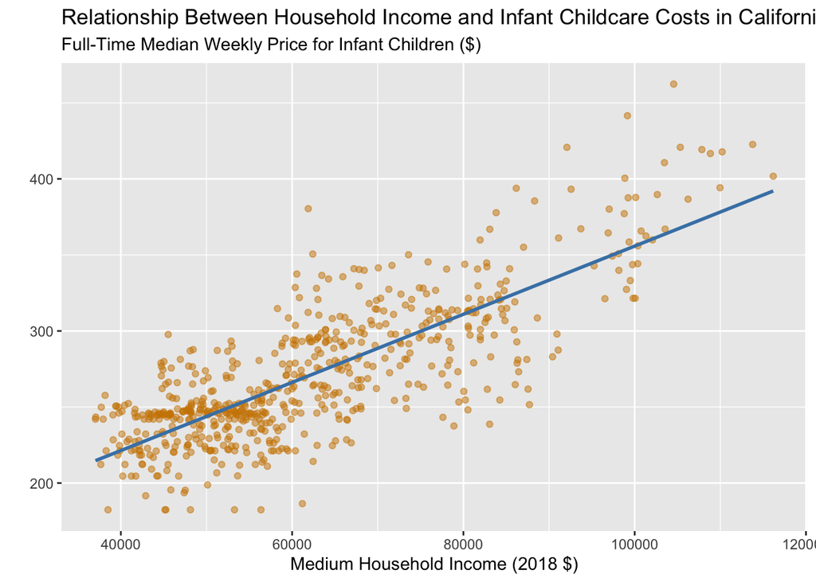

```r
# Source: https://thomasadventure.blog/posts/ggplot-regression-line/#:~:text=To%20make%20geom_smooth()%20draw,short%20for%20%E2%80%9Clinear%20model%E2%80%9D.&text=The%20gray%20shading%20around%20the,by%20changing%20the%20level%20parameter.

ca_childcare |>
  ggplot(mapping = aes(x = mhi_2018,
                       y = mc_infant)) +
  geom_point(position = "jitter",
             alpha = 0.5,
             color = "orange3") +
  geom_smooth(method = "lm",
              se = FALSE,
              color = "steelblue") +
  labs(x = "Medium Household Income (2018 $)",
       y = "",
       subtitle = "Full-Time Median Weekly Price for Infant Children ($)",
       title = "Relationship Between Household Income and Infant Childcare Costs in California")
```

**8. Look up the documentation for `lm()` and fit a linear regression model to the relationship shown in your plot above.**

```r
# complete the code provided
reg_mod1 <- lm(mc_infant ~ mhi_2018, data = ca_childcare)
summary(reg_mod1)
```

```
Call:
lm(formula = mc_infant ~ mhi_2018, data = ca_childcare)

Residuals:
    Min      1Q  Median      3Q     Max
-82.407 -15.606   0.097  15.999 110.026

Coefficients:
             Estimate Std. Error t value Pr(>|t|)
(Intercept) 1.317e+02  4.321e+00   30.49   <2e-16 ***
mhi_2018    2.241e-03  6.737e-05   33.26   <2e-16 ***
---
Signif. codes:  0 '***' 0.001 '**' 0.01 '*' 0.05 '.' 0.1 ' ' 1

Residual standard error: 27.48 on 636 degrees of freedom
Multiple R-squared:  0.635, Adjusted R-squared:  0.6344
F-statistic:  1106 on 1 and 636 DF,  p-value: < 2.2e-16
```

**9. Using the output from `summary()`, write out the estimated regression line (recall: $y = mx + b$).**

Estimated regression line: `$y = 0.002241x + 131.7`

where `y` is the response variable `mc_infant` and `x` is the predictor variable `mhi_2018`

**10. Do you have evidence to conclude there is a relationship between the median household income and the median weekly cost of center-based childcare for infants in California? Cite values from your `summary()` output to support your claim!**

Based on the data from the linear model, we do have evidence to conclude that there is a relationship between the median household income and the median weekly cost of center-based childcare for infants in California. From the data in the `summary()` output of the linear model, the p-value associated with the slope coefficient for `mhi_2018` is < 2e-16, which is significantly less than 0.05. This indicates statistical significance, and suggests that we can reject the null hypothesis that there is no relationship between the two. Moreover, by analyzing the R-squared value of 0.635, this suggests that the 63.5% of the variability in the median weekly cost of childcare for infants can be explained by the median household income, indicating a strong correlation between the two variables.